# Mini Project 3

2025-04-23

## Front Matter

```r
remove(list = ls())

library(tidyverse)
library(readxl)
library(glmnet)
library(MASS)
library(rpart)
library(rattle)
#CODGames2_mp <- read_excel("CODGames2_mp.xlsx")
CODGames2_mp <- read_excel("C:/Users/Blungus/OneDrive - The Pennsylvania State University/2024-25/Spring Sem/Stat 380/Test CSV files/CODGames2_mp.xlsx")
```

## Problem 1

```r
cod_full <- CODGames2_mp %>%
  filter(FullPartial == "Full")
```

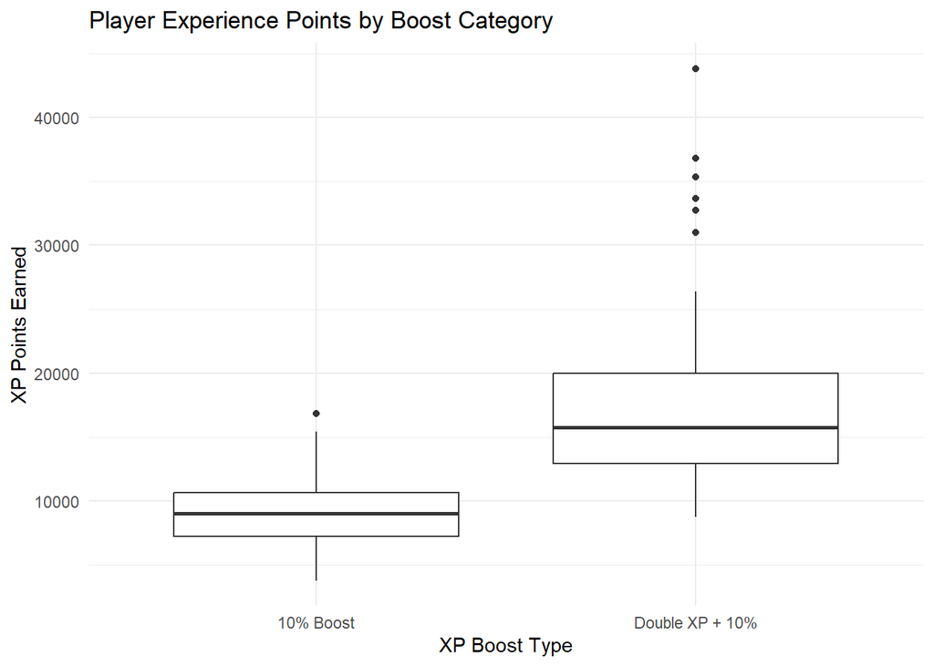

```r
ggplot(data = cod_full, aes(x = XPType, y = TotalXP)) +
  geom_boxplot() +
  labs(x = "XP Boost Type",
       y = "XP Points Earned",
       title = "Player Experience Points by Boost Category") +
  theme_minimal()
```

```r
xp_summary <- cod_full %>%
  group_by(XPType) %>%
  summarize(
    Count = n(),
    Mean = mean(TotalXP),
    Median = median(TotalXP),
    Min = min(TotalXP),
    Max = max(TotalXP),
    StdDev = sd(TotalXP)
  )

xp_summary
```

```
## # A tibble: 2 × 7
##   XPType          Count   Mean Median   Min   Max StdDev
##   <chr>           <int>  <dbl>  <dbl> <dbl> <dbl>  <dbl>
## 1 10% Boost         111  9094.   9039  3795 16831  2606.
## 2 Double XP + 10%    80 17242.  15738  8772 43816  6649.
```

The data shows players who play “Double XP + 10%” earn more points than those playing “10% Boost”. With a mean of 17,242.17 compared to 9,094.45, players earn almost twice as many points in Double XP games. The median values (15,738 vs. 9,039) confirm this pattern. Double XP games show more variation in points earned (6,648.59 vs. 2,605.95). Players who want to level up fast should play during Double XP events.

## Problem 2

### a.

```r
# Convert 'Result' into 'TeamScore' and 'OpponentScore', then into 'outcome'
cod_full <- cod_full %>%
  separate(Result,into = c("TeamScore", "OpponentScore"), sep = "-", convert = TRUE)%>%
  mutate(Outcome = case_when(
    TeamScore > OpponentScore ~ "Win",
    TeamScore < OpponentScore ~ "Loss",
    TRUE ~ "Tie"
  ))

# indicator based on 'XPType'
cod_full$XPType <- ifelse(cod_full$XPType == "10% Boost", 1, 0)

# indicator based on outcomes for 'Win'
cod_full$Win <- ifelse(cod_full$Outcome == "Win", 1, 0)



# only TDM
cod_TDM_full <- cod_full %>%
  filter(GameType == "HC - TDM")



# create matrix > LASSO
X <- model.matrix(Score ~ TotalXP + Eliminations + Deaths + Damage + XPType + Win,
                  data = cod_TDM_full)[,-1]
y <- cod_TDM_full$Score
```

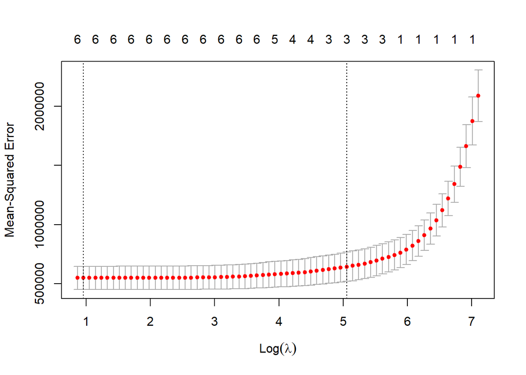

```r
# Lasso CV using X and y
set.seed(123)
lassoFit <- cv.glmnet(X, y, alpha = 1)

# plot
plot(lassoFit)
```

```r
# best lambda
best_lambda <- lassoFit$lambda.min
best_lambda
```

```
## [1] 2.611974
```

```r
# coefficients for best lambda
coef(lassoFit, s = best_lambda)
```

```
## 7 x 1 sparse Matrix of class "dgCMatrix"
##                         s1
## (Intercept)   575.58142972
## TotalXP         0.05984054
## Eliminations  159.12937918
## Deaths        -72.77820466
## Damage          0.94772672
## XPType        361.57550500
## Win          -447.19199686
```

#### The optimal penalty is λ = 2.611974.

#### non-zero coefficients:

- TotalXP: For every XP point, score increases by 0.0598 points
- Eliminations: Every elimination increases the score by 159.129 points
- Deaths: Each death decreases score by 72.778 points
- Damage: Each point of damage increases the score by 0.9477
- XPType (10% Boost): Games with the 10% XP Boost increases the score by 361.5755 points
- Win: If the player wins, the score will decrease by 447.1919 points

```r
# Fit model > stepwise
lm_full <- lm(Score ~ TotalXP + Eliminations + Deaths + Damage + XPType + Win,
              data = cod_TDM_full)

# stepwise selection
step_model <- step(lm_full)
```

```
## Start:  AIC=2342.53
## Score ~ TotalXP + Eliminations + Deaths + Damage + XPType + Win
##
##                Df Sum of Sq      RSS    AIC
## - Damage        1    119968 85565679 2340.8
## <none>                      85445711 2342.5
## - Eliminations  1   2766940 88212652 2346.2
## - XPType        1   3222207 88667919 2347.1
## - Win           1   7727591 93173302 2355.9
## - TotalXP       1  10431500 95877211 2361.0
## - Deaths        1  11752728 97198439 2363.5
##
## Step:  AIC=2340.78
## Score ~ TotalXP + Eliminations + Deaths + XPType + Win
##
##                Df Sum of Sq       RSS    AIC
## <none>                       85565679 2340.8
## - XPType        1   3103670  88669349 2345.1
## - Win           1   7627935  93193614 2354.0
## - TotalXP       1  10318883  95884562 2359.0
## - Deaths        1  11660493  97226172 2361.5
## - Eliminations  1 118217717 203783396 2493.2
```

```r
summary(step_model) #for interpretation purpose.
```

```
##
## Call:
## lm(formula = Score ~ TotalXP + Eliminations + Deaths + XPType +
##     Win, data = cod_TDM_full)
##
## Residuals:
##      Min       1Q   Median       3Q      Max
## -2000.77  -444.28   -35.43   327.75  2912.93
##
## Coefficients:
##                Estimate Std. Error t value Pr(>|t|)
## (Intercept)   576.11301  353.95152   1.628  0.10543
## TotalXP         0.06054    0.01329   4.554 9.91e-06 ***
## Eliminations  185.24081   12.01658  15.415  < 2e-16 ***
## Deaths        -73.25104   15.13007  -4.841 2.86e-06 ***
## XPType        367.94000  147.30748   2.498  0.01344 *
## Win          -454.44701  116.05540  -3.916  0.00013 ***
## ---
## Signif. codes:  0 '***' 0.001 '**' 0.01 '*' 0.05 '.' 0.1 ' ' 1
##
## Residual standard error: 705.3 on 172 degrees of freedom
## Multiple R-squared:  0.7697, Adjusted R-squared:  0.763
## F-statistic:   115 on 5 and 172 DF,  p-value: < 2.2e-16
```

```r
# LASSO
lasso_vars <- rownames(coef(lassoFit, s = best_lambda))[coef(lassoFit, s = best_lambda)[, 1] != 0]
lasso_vars <- lasso_vars[lasso_vars != "(Intercept)"]
lasso_vars
```

```
## [1] "TotalXP"      "Eliminations" "Deaths"       "Damage"       "XPType"
## [6] "Win"
```

```r
# stepwise
stepwise_vars <- names(coef(step_model))[-1]
stepwise_vars
```

```
## [1] "TotalXP"      "Eliminations" "Deaths"       "XPType"       "Win"
```

LASSO and Stepwise identified (TotalXP, Eliminations, Deaths, Win and XPType) as a good predictors of score. This suggests that these are highly influential in different methods.

The difference is that LASSO included Damage, which Stepwise excluded. LASSO retain more variables even a small improvement in fit, but Stepwise prioritizes less/fewer variables with minimal loss in.

The 2 methods agree. The core predictors (TotalXP, Eliminations, Deaths, Win, and XPType) are used across both models. Damage may still factor into score, but stepwise determined it was not relevant to include.

### b.

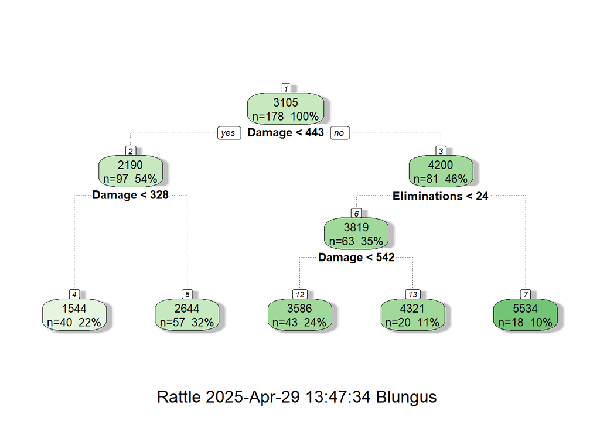

```r
# Decision tree model
set.seed(123)
tree_model <- rpart(Score ~ TotalXP + Eliminations + Deaths + Damage + XPType + Win,
                    data = cod_TDM_full,
                    method = "anova",
                    control = rpart.control(minbucket = 15))

fancyRpartPlot(tree_model, cex = 0.8)
```

```r
# Top 3 predictors
# summary(tree_model)
100*tree_model$variable.importance/sum(tree_model$variable.importance)
```

```
##       Damage Eliminations      TotalXP       Deaths          Win       XPType
##    39.807799    37.696686    10.216599     6.336862     4.194392     1.747663
```

The top 3 variables of importance when it comes to predicting score using ‘total XP’, ‘eliminations’, ‘deaths’, ‘damage’, ‘XPType’, and whether the player’s team won (‘Win’) are as follows:

1. Damage:
- Importance value of 39.807799
2. Eliminations:
- Importance value of 37.696686
3. TotalXP:
- Importance value of 10.216599

### C.

```r
# Standardize
cod_TDM_scaled <- cod_TDM_full %>%
  mutate(Score=scale(Score),
         TotalXP=scale(TotalXP),
         Eliminations=scale(Eliminations),
         Deaths=scale(Deaths),
         Damage=scale(Damage),
         XPType=scale(XPType),
         Win=scale(Win))

# Fit model > standardized stepwise
lm_standardized_full <- lm(Score ~ TotalXP + Eliminations + Deaths + Damage + XPType + Win,
              data = cod_TDM_scaled)
# Standardized stepwise selection
step_standardized_model <- step(lm_standardized_full)
```

```
## Start:  AIC=-248.65
## Score ~ TotalXP + Eliminations + Deaths + Damage + XPType + Win
##
##                Df Sum of Sq    RSS     AIC
## - Damage        1    0.0571 40.756 -250.40
## <none>                      40.699 -248.65
## - Eliminations  1    1.3179 42.017 -244.98
## - XPType        1    1.5348 42.234 -244.06
## - Win           1    3.6808 44.380 -235.24
## - TotalXP       1    4.9687 45.668 -230.15
## - Deaths        1    5.5980 46.297 -227.71
##
## Step:  AIC=-250.4
## Score ~ TotalXP + Eliminations + Deaths + XPType + Win
##
##                Df Sum of Sq    RSS      AIC
## <none>                      40.756 -250.402
## - XPType        1     1.478 42.235 -246.060
## - Win           1     3.633 44.390 -237.202
## - TotalXP       1     4.915 45.671 -232.135
## - Deaths        1     5.554 46.310 -229.662
## - Eliminations  1    56.309 97.065  -97.939
```

```r
# Storing new coefficients
stepwise_standardized_vars <- names(coef(step_standardized_model))[-1]

# Display new coefficients and linear model
stepwise_standardized_reg_final <- lm(as.formula(paste("Score ~", paste(stepwise_standardized_vars, collapse = " + "))),
                                      data = cod_TDM_scaled)

stepwise_standardized_coef<- summary(stepwise_standardized_reg_final)$coefficients

magnitudes<- abs(stepwise_standardized_coef[, "Estimate"])
sorted_magnitudes <- sort(magnitudes, decreasing = TRUE)

options(scipen = 999)
100*sorted_magnitudes/sum(sorted_magnitudes)
```

```
##             Eliminations                  TotalXP                   Deaths
## 49.109823528637058132063 18.239186264704208895182 13.171149670615804438967
##                      Win                   XPType              (Intercept)
## 10.771574384706839921932  8.708266151336092164570  0.000000000000007002746
```

When considering the linear regression model that came out of stepwise feature selection, the top 3 variables of importance when predicting score using ‘total XP’, ‘eliminations’, ‘deaths’, ‘XPType’, and whether the player’s team won (‘Win’) are as follows:

1. Eliminations:
- Magnitude of importance: 49.1098
2. TotalXP:
- Magnitude of importance: 18.2391
3. Deaths:
- Magnitude of importance: 13.1711

The stepwise feature selection decided to remove the ‘Damage’ variable to provide the best result for predicting ‘Score’, so naturally the next most important variable was ‘Deaths’, as it was right behind ‘TotalXP’ ranked 4th in importance in the regression tree model’s coefficients. The regression tree values of importance for ‘Damage’ and ‘Eliminations’ were very close to each other, leading to a large drop off once ‘TotalXP’ was considered. In the regression model above, however, ‘Eliminations’ carries the most weight as it drops off heavily next to the magnitudes of importance for ‘TotalXP’ and ‘Deaths’. This lines up as expected because the top coefficient in the regression tree was ‘Damage’, so removing that from the model allows ‘Deaths’ to fit into the top 3.

## Group Evaluations

### Omer Kandemir

Omer worked on all of task 1, which was the analysis/boxplots associated with the ‘XPType’ and ‘TotalXP’. He provided ample discussion and made the plots clear and easy to understand. Some comments could be added for conciseness, but that did not detract from his overall performance.

### Rayan Abumansi

Rayan was tasked with working on the first half of task 2, including parts a and b. However, he asked for assistance with the latter half of part b since he was stumped on the top 3 indicators, so I added that to my personal contribution for the mini-project. Rayan’s code and decision trees ran as they should, but he incorrectly created the ‘Win’ variable, so some discussion/results were amended in my section. He did a very good job with commenting each part of the code for better readability. Strong discussion on model comparison.

### Logan Camacho

I was tasked with finishing problem 2 part b and part c, as well as doing an overall proofread and debug of the entire project to ensure we did not miss anything important within the mini-project. As previously mentioned, I had to amend problem 2 part a’s code to properly reflect ‘Win’ and ‘XPType’ as indicators before standardizing, but overall saw no fatal errors amongst the group. Part c was the most computationally intensive part, so I took the time to understand the code in order to properly report outcomes in our discussion.